# Lab 3A

Classification with (regularized) Logistic Regression, and LDA

2026

# Getting Started: Loading the Dataset

Before you begin the practical, you need to load the required dataset into R. To ensure a smooth workflow, please follow one of the two options below:

**Option 1: Using a Dedicated Folder**

Create a specific folder for this assignment and place the dataset file inside it. You can then load the data using the `load()` function by specifying the correct file path. (Note for Windows users: Please ensure you change all backslashes `\` in your copied file path to forward slashes `/` in R).

For **Mac** users, your path will look like this:

```r
load("/Users/your_username/Documents/folder_name/dataset_name.RData")
```

For **Windows** users, your path will look like this:

```r
load("C:/Users/your_username/Documents/folder_name/dataset_name.RData")
```

**Option 2: Using an R Project**

Create an R Project (`.Rproj`) for this assignment and store the dataset directly within that project folder. Make sure to open RStudio by double-clicking the `.Rproj` file. This automatically sets your working directory, allowing you to load the dataset directly without a long path:

```r
load("dataset_name.RData")
```

**Note for this specific lab:** While the above options outline the standard workflow for local files, you do not need to download or load a .RData file for this specific lab. Today, we will access our data directly through the kernlab package using the data(“spam”) command.

In this lab you train models to classify emails as either spam or non-spam based 57 features of the email. The data set for this lab is `spam` from the package `kernlab`. The variable `type` contains the classifications. Other packages you need are `MASS`, `glmnet`, `caret` and `pRoc`.

## The Spam dataset

The dataset `spam` from the package `kernlab` contains information about emails and whether they are classified as **spam** or **non-spam**.

- The dataset contains **4601 emails**.
- Each email is described by **57 numeric features**.
- These features measure properties of the email such as:
  - frequency of specific words (e.g. *free*, *money*, *remove*)
  - frequency of special characters (e.g. `!`, `$`)
  - statistics related to capital letters.

The response variable `type` indicates whether the email is:

- `"spam"` – unsolicited or unwanted email
- `"nonspam"` – legitimate email

The goal of this lab is to build **classification models** that can predict whether an email is spam based on these features.

# Data exploration

1. Load the necessary packages, and load the `spam` data in workspace with the function `data()`. Check its help file for the description of the data.

   **Hint:** If you haven’t installed `kernlab` or `pROC` yet, you will need to run `install.packages()` first. Use `?spam` to view the documentation.

**Show Answer**

```r
library(kernlab)
library(MASS)
library(glmnet)
library(dplyr)
library(tidyr)
library(pROC)
library(caret)
data("spam")
```

2. Display the boxplots of the standardized features (so exclude the variable `type`). What does these plots tell you about the distributions of the features?

   **Hint:** Use the `scale()` function to standardize the features before plotting. Look at the range and the dots representing outliers.

**Show Answer**

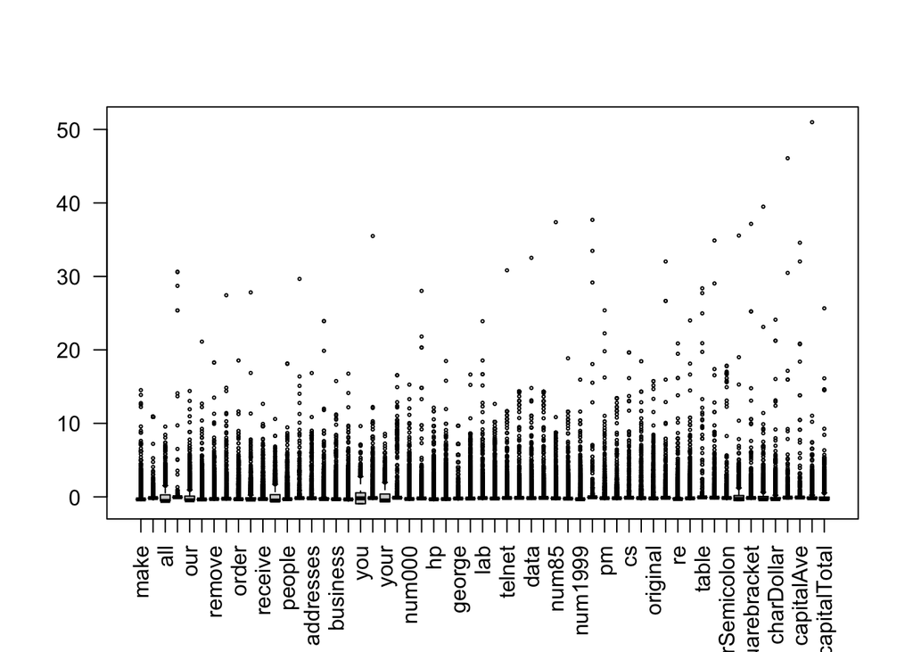

```r
boxplot(scale(spam[, -58]), cex = .3, las = 2)
```

```r
# The scale() function standardizes the features for comparison.
# The resulting boxplots show tightly clustered medians but massive outliers, indicating highly right-skewed distributions.
```

As you can see the predictors have strongly skewed distributions with many outliers, which motivates the log transformation applied in the next step of the lab.

3. To reduce the magnitude of the outliers, make the data `logspam` containing the standardized logarithms of the each feature (add 1 to each feature to avoid taking the log of 0), and plot the the features to check the effects of the transformations on the $z$-scores.

   **Hint:** You can use `dplyr` functions like `mutate` and `across`, or apply the transformation using base R.

**Show Answer**

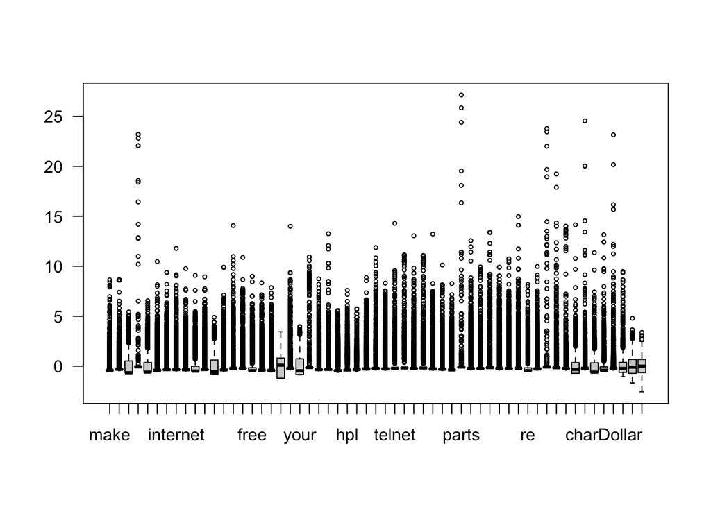

```r
# Applying log(x + 1) transformation shrinks extreme values and reduces skewness.
# Standardizing them afterwards makes the scales comparable across all 57 features.
logspam <- spam %>%
  mutate(across(-58, ~ scale(log(.x + 1))))

boxplot(logspam[, -58], cex = .5, las = 1)
```

# Data partitioning

We first make a vector to partition the data in a training set consisting of 75% of the data, and a test of 25% of the data.

1. Set the seed to 10 for reproducibility, and make the vector `train` consisting of 75% of the row numbers.

   **Hint:* `createDataPartition()` from the `caret` package ensures that the proportion of spam/nonspam is balanced between the train and test sets.

**Show Answer**

```r
# Setting a seed guarantees we get the exact same random split every time we run the script.
# The train object stores the row indices for the training data (75% of total).
set.seed(10)
train <- createDataPartition(y = logspam$type, p = .75, list = FALSE)
```

# Model training

We first train the three logistic regression models (one without and two with regularization), and the linear discriminant model.

## Logistic regression

1. Fit the logistic regression model with all 57 features to the training set, and save the object as `train_glm`.

   **Hint:** Use the `glm()` function and specify `family = "binomial"` for binary classification.

**Show Answer**

```r
# Fitting a standard logistic regression model using all features.
# R may throw a warning about fitted probabilities numerically 0 or 1, pointing to perfect separation in some features.
train_glm <- glm(type ~ . , family = "binomial", data = logspam[train, ])
```

The warning `glm.fit: fitted probabilities numerically 0 or 1 occurred` implies that one or more features have extreme parameter estimates and standard errors.

2. Display the parameter estimates with `coef(summary(train_glm))`, rounded to two decimals, and identify the features with extreme parameters estimates and standard errors.

   **Hint:** Look down the ‘Estimate’ and ‘Std. Error’ columns for unusually large numbers compared to the rest of the variables.

**Show Answer**

```r
# The summary reveals which features drive the separation.
# Variables with enormous estimates and standard errors are suffering from instability (often due to sparsity or multicollinearity).
round(coef(summary(train_glm)), 2)
```

```
##                   Estimate Std. Error z value Pr(>|z|)
## (Intercept)         -13.40     426.58   -0.03     0.97
## make                 -0.18       0.10   -1.84     0.07
## address              -0.07       0.09   -0.75     0.46
## all                  -0.13       0.08   -1.55     0.12
## num3d                 1.09       0.96    1.14     0.26
## our                   0.53       0.08    6.35     0.00
## over                  0.26       0.09    3.05     0.00
## remove                0.74       0.13    5.92     0.00
## internet              0.28       0.09    3.22     0.00
## order                 0.07       0.10    0.71     0.48
## mail                  0.20       0.08    2.42     0.02
## receive              -0.06       0.08   -0.80     0.43
## will                 -0.17       0.09   -1.93     0.05
## people               -0.13       0.09   -1.46     0.14
## report                0.22       0.08    2.77     0.01
## addresses             0.16       0.19    0.85     0.40
## free                  0.49       0.08    5.83     0.00
## business              0.34       0.11    3.05     0.00
## email                -0.01       0.09   -0.08     0.93
## you                   0.10       0.10    1.02     0.31
## credit                0.32       0.14    2.27     0.02
## your                  0.27       0.10    2.76     0.01
## font                  0.07       0.14    0.49     0.62
## num000                0.53       0.15    3.47     0.00
## money                 0.29       0.08    3.81     0.00
## hp                   -1.88       0.29   -6.43     0.00
## hpl                  -0.48       0.27   -1.80     0.07
## george              -10.67       1.92   -5.55     0.00
## num650                0.37       0.12    3.11     0.00
## lab                  -0.64       0.41   -1.55     0.12
## labs                 -0.23       0.18   -1.29     0.20
## telnet                0.08       0.19    0.42     0.68
## num857               -0.16       0.81   -0.19     0.85
## data                 -0.24       0.12   -1.92     0.06
## num415               -0.28       0.38   -0.74     0.46
## num85                -1.01       0.33   -3.09     0.00
## technology            0.25       0.13    1.91     0.06
## num1999              -0.16       0.12   -1.37     0.17
## parts                 0.15       0.14    1.08     0.28
## pm                   -0.16       0.14   -1.12     0.26
## direct               -0.17       0.17   -0.99     0.32
## cs                  -57.45    2887.03   -0.02     0.98
## meeting              -1.13       0.31   -3.68     0.00
## original             -0.48       0.29   -1.67     0.09
## project              -0.50       0.20   -2.54     0.01
## re                   -0.46       0.11   -4.15     0.00
## edu                  -0.92       0.19   -4.88     0.00
## table                -0.17       0.17   -0.99     0.32
## conference           -0.57       0.25   -2.24     0.03
## charSemicolon        -0.27       0.10   -2.67     0.01
## charRoundbracket     -0.17       0.09   -1.93     0.05
## charSquarebracket    -0.04       0.12   -0.35     0.73
## charExclamation       0.67       0.09    7.50     0.00
## charDollar            0.94       0.15    6.34     0.00
## charHash              0.14       0.22    0.62     0.53
## capitalAve            0.40       0.20    2.03     0.04
## capitalLong           0.11       0.23    0.47     0.64
## capitalTotal          0.97       0.18    5.34     0.00
```

## LASSO and ridge regression

Shrinkage avoids extremely large parameter estimates. The function `glmnet()` performs both lasso and ridge regression.

1. Train the logistic regression model with the LASSO and the ridge. Do not forget that argument `x` requires a `matrix` as input, and to set the `familiy` to `"binomial"`. Save the objects as `train_lasso` and `train_ridge`.

   **Hint:** `alpha = 1` (the default) fits a LASSO model, while `alpha = 0` fits a Ridge model. Convert the predictors using `as.matrix()`.

**Show Answer**

```r
# LASSO (alpha = 1) performs variable selection by shrinking some coefficients to exactly zero.
train_lasso <- glmnet(x = as.matrix(logspam[train, -58]),
                      y = logspam[train, 58],
                      family = "binomial")
# Ridge (alpha = 0) shrinks coefficients continuously toward zero, but keeps all variables in the model.
train_ridge <- glmnet(x = as.matrix(logspam[train, -58]),
                      y = logspam[train, 58],
                      family = "binomial",
                      alpha = 0)
```

2. Plot both objects using the arguments `label = TRUE` and `xvar = "lambda"`.  
   Here, `label = TRUE` shows the predictor names in the plot, and `xvar = "lambda"` places the penalty parameter `lambda` on the x-axis. The plots display the coefficient paths as a function of `lambda`: as `lambda` increases, the coefficients are increasingly shrunk toward zero. Which coefficients are most strongly affected by this shrinkage?

   **Hint:** Look at the lines that start with very high absolute values on the left side of the plot and rapidly drop towards the zero line.*

**Show Answer**

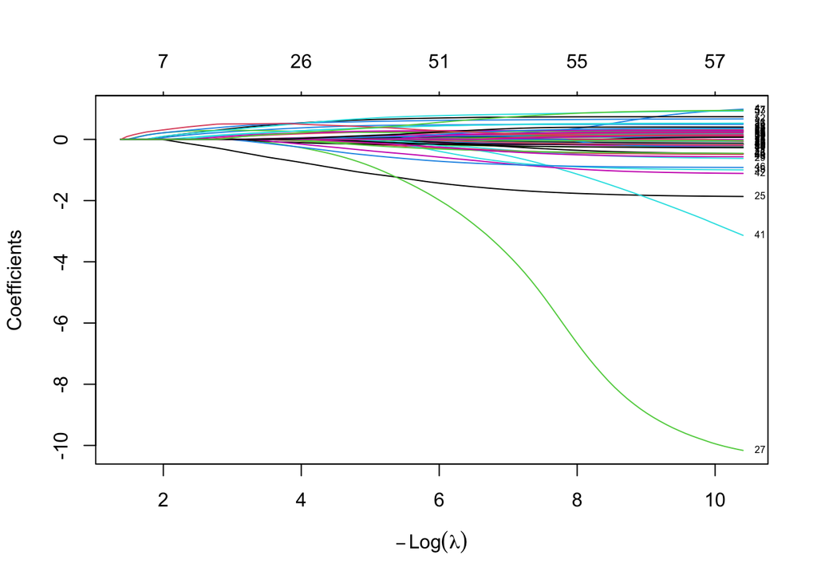

```r
# These plots visualize the coefficient paths.
# Notice how LASSO drops features completely out of the model earlier, while Ridge shrinks them asymptotically.
plot(train_lasso, label = TRUE, xvar="lambda")
```

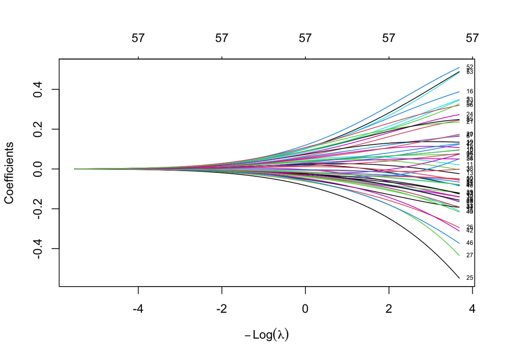

```r
plot(train_ridge, label = TRUE, xvar="lambda")
```

3. Perform a 5-fold cross-validation to determine the optimal value for the shrinkage parameters `lambda` with `cv.glmnet()`. Save the objects as `train_cv.lasso` and `train_cv.ridge`. Set the seed to 1 for reproducibility.

   **Hint:** Use the `nfolds = 5` argument. `cv.glmnet()` will automatically test a sequence of lambda values to find the one with the lowest error.*

**Show Answer**

```r
# Cross-validation identifies the optimal penalty parameter (lambda) that minimizes out-of-sample deviance.
set.seed(1)
train_cv.lasso <- cv.glmnet(x = as.matrix(logspam[train, -58]),
                            y = logspam[train, 58],
                            family = "binomial",
                            nfolds = 5)
train_cv.ridge <- cv.glmnet(x = as.matrix(logspam[train, -58]),
                            y = logspam[train, 58],
                            family = "binomial",
                            nfolds = 5,
                            alpha = 0)
```

4. Plot the objects `train_cv.lasso` and `train_cv.lasso`, and interpret the plots.

   **Hint:** The dashed vertical lines represent the optimal `lambda` (minimum error) and the `lambda` within 1 standard error of the minimum. The y-axis shows the binomial deviance (error measure).